# brms model report: ita_3_roma

### Rainfall in the last day (scaled)

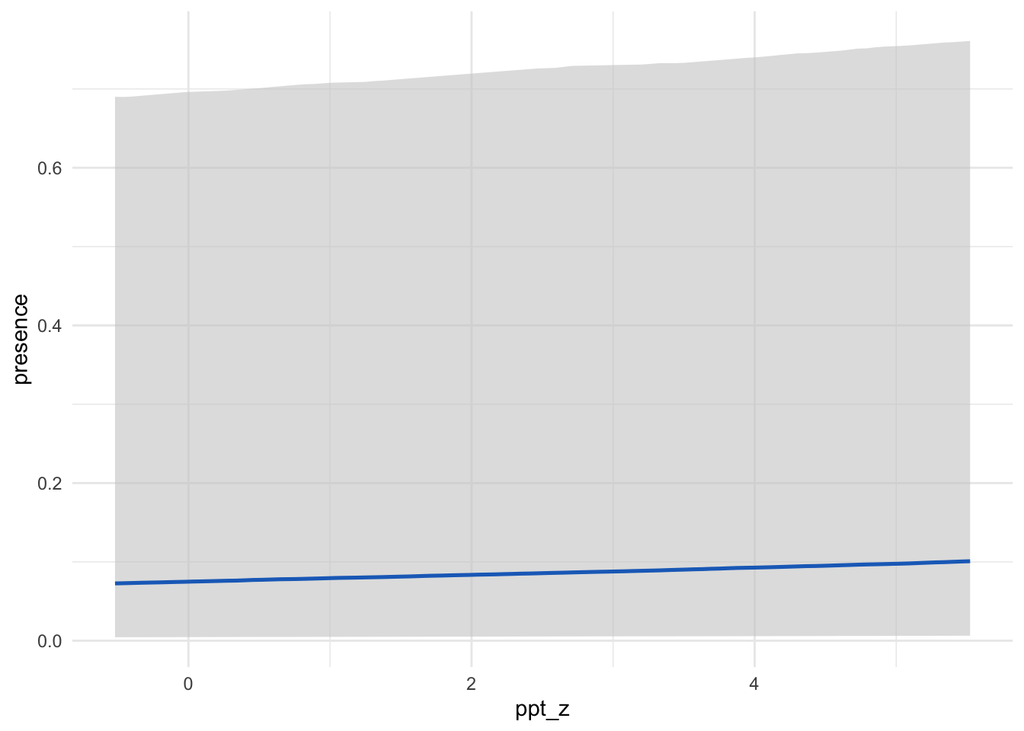

### Green-space proximity (NDVI)

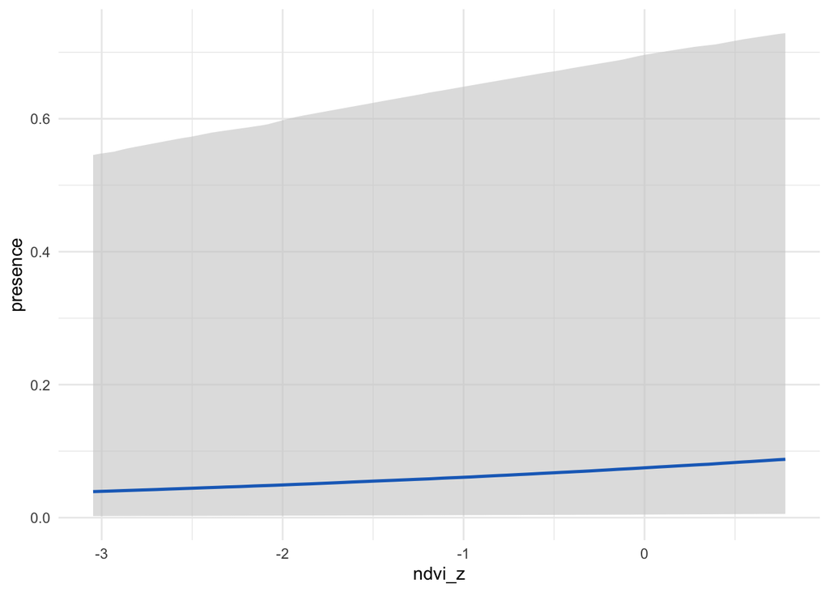

### Elevation (scaled)

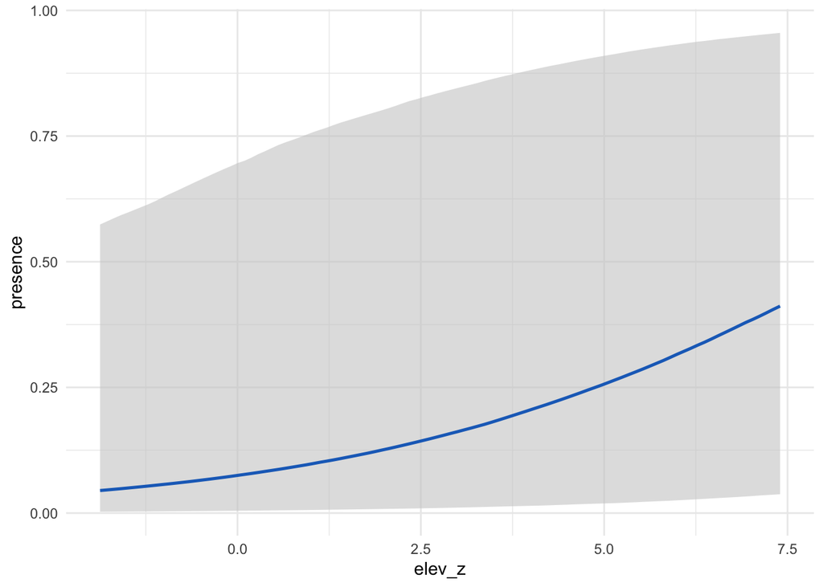

### Day of the year

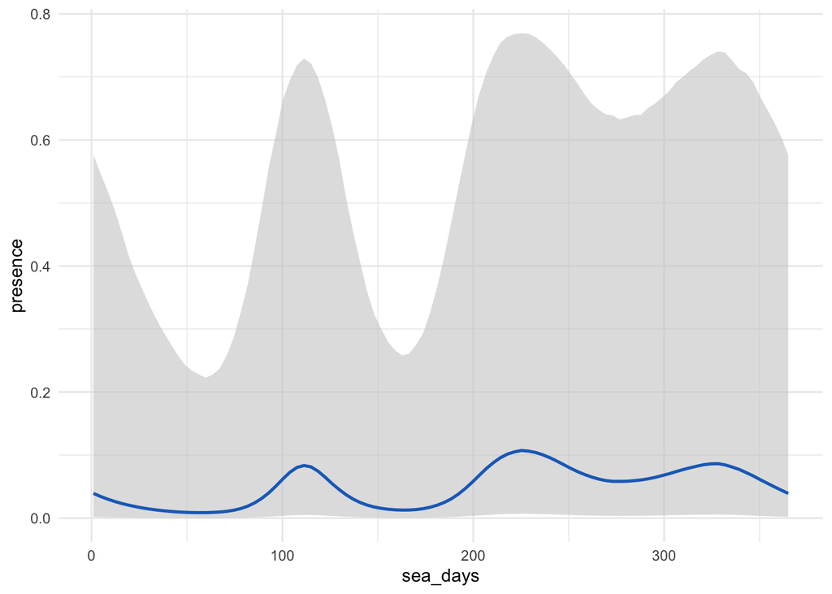

### Maximum temperature (scaled)

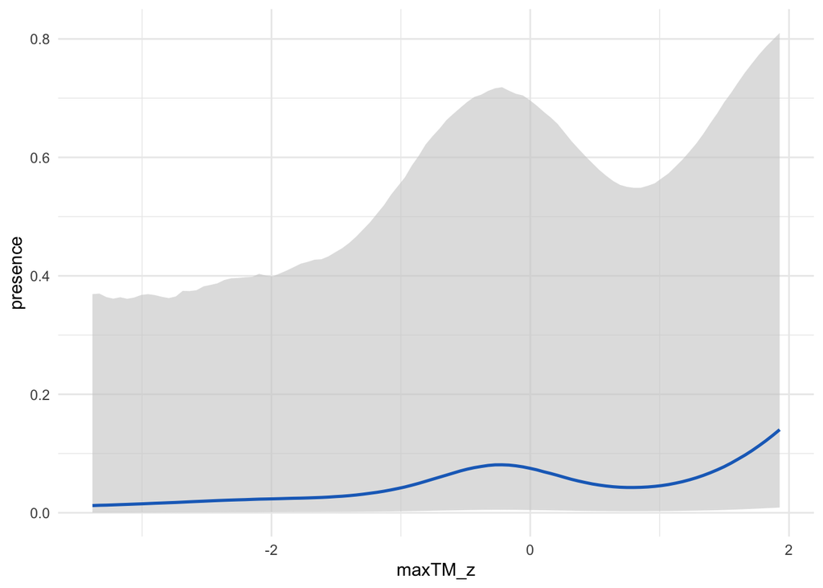

## Land-cover random effects

| landcover | term | estimate | est_error | lower | upper |
| --- | --- | --- | --- | --- | --- |
| 0 | Intercept | 5.74 | 2.76 | 1.76 | 12.37 |
| 60 | Intercept | 3.65 | 3.16 | -1.29 | 11.03 |
| 50 | Intercept | 0.67 | 1.50 | -2.54 | 3.37 |
| 10 | Intercept | -0.72 | 1.50 | -3.93 | 2.00 |
| 90 | Intercept | -2.76 | 3.41 | -11.01 | 2.02 |
| 30 | Intercept | -2.89 | 1.61 | -6.34 | -0.02 |
| 20 | Intercept | -3.10 | 1.81 | -7.14 | 0.03 |
| 80 | Intercept | -3.60 | 3.37 | -12.10 | 0.95 |
| 40 | Intercept | -4.31 | 1.80 | -8.30 | -1.18 |